# Plato, cocina, receta, ingredientes #5

Postre logístico para la 2da vuelta

Nelson Amaya

Twitter: [`@nelsonamayad`](https://twitter.com/NelsonAmayaD)  
Publicación: **10-06-2018**

> *“This self-deceit, this fatal weakness of mankind, is the source of half the disorders of human life”*  
> - [Adam Smith](http://www.econlib.org/library/Smith/smMS.html)

Llegó la hora de ver si la presidencia de Colombia en 2018 queda en cabeza de [`@IvanDuque`](https://twitter.com/IvanDuque) o [`@GustavoPetro`](https://twitter.com/GustavoPetro). Ya se hizo la tarea para la primera vuelta y [los resultados fueron muy buenos](https://nelsonamayad.github.io/caldo/caldo), a pesar de que no capturaron la sorpresa fajardista que le sacó varios puntos a Petro y a De la Calle en la última semana.

Este postre busca lograr lo que los anteriores no pudieron: estimar qué tan probable es que gane uno u otro candidato. Para hacer eso el postre le aplica una transformación sencillita al plato [Simple](https://nelsonamayad.github.io/mixto/mixto): en vez de servir dos recetas por candidato, se sirve una sola [logística](https://en.wikipedia.org/wiki/Logistic_regression) para ambos. Esto permite generar un pronóstico probabilístico para la segunda vuelta.

¿Por qué hacerlo así? Porque según las encuestas la victoria es para Duque: todas coinciden en que el candidato de la coalición de derecha obtiene una mayor proporción de votos que su contrincante. Es más, el resultado del [plato mixto](https://nelsonamayad.github.io/mixto/mixto), al que mejor le fue en la primera vuelta, aplicado a las encuestas que salieron después del 27 de mayo da como resultado que **Duque obtendrá 51% de la votación, con un rango intervalo HPD de 95% de entre 46% y 57%, y Petro obtendría 37%, con un rango HPD de 95% entre 34% y 41%**. Así que en vez de decir lo obvio, nos vamos por lo menos evidente, aunque sea más difícil de masticar.

Buen provecho.

## Postre Logístico

Este postre recoge la probabilidad de que [`@IvanDuque`](https://twitter.com/IvanDuque) sea presidente, estimada por el modelo que se describe abajo.

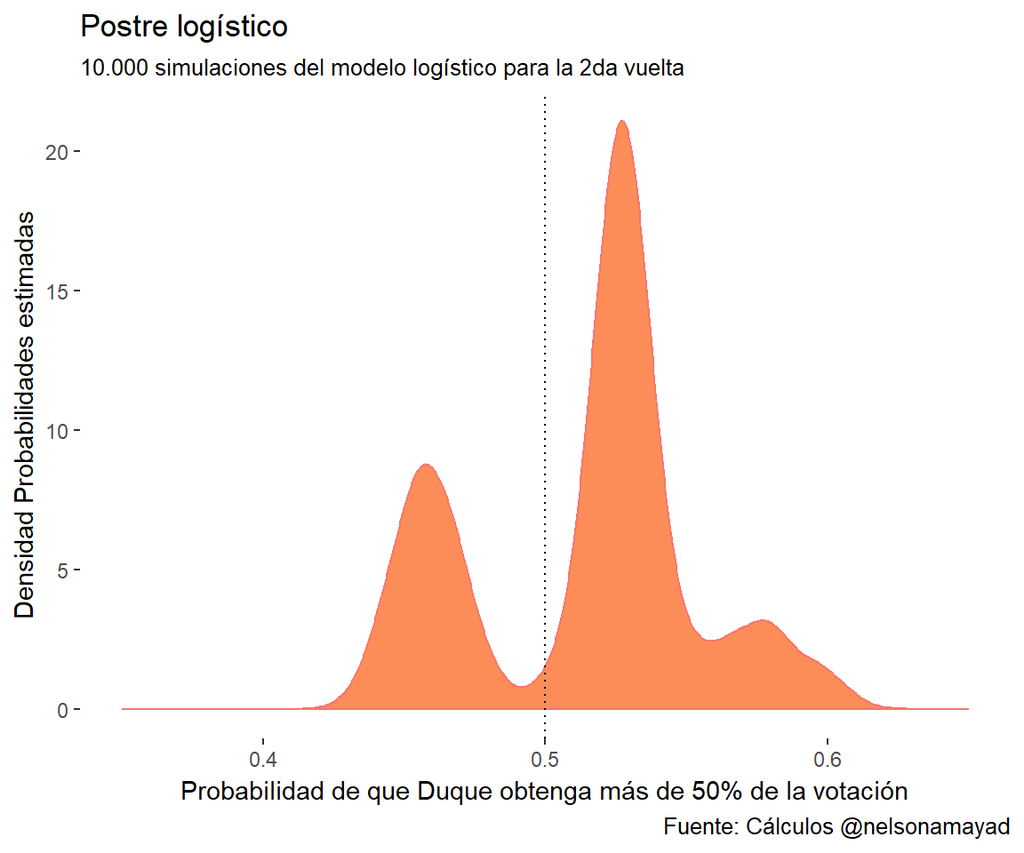

```r
library(ggplot2)
library(RCurl)

#Importar simulaciones
id.4cast <- read.csv(text=getURL("https://raw.githubusercontent.com/nelsonamayad/nelsonamayad.github.io/master/logis/id4cast.csv"))

#postre logis
ggplot(id.4cast)+
  geom_density(aes(x=id4cast,fill="orangered3",color="grey60"))+
  geom_vline(xintercept=0.5,linetype="dotted")+
labs(x="Probabilidad de que Duque obtenga más de 50% de la votación",y="Densidad Probabilidades estimadas",
       title="Postre logístico",
       subtitle="10.000 simulaciones del modelo logístico para la 2da vuelta",
       caption = "Fuente: Cálculos @nelsonamayad")+
  theme(legend.position = "none",
        panel.background = element_blank())+
  xlim(0.35,0.65)+
  scale_fill_brewer(palette = "Spectral")
```

### Ingredientes

Los únicos ingredientes de esta receta son las encuestas que han salido desde la primera vuelta. Como *priors* se toman los promedios y desviaciones estándar de cada candidato.

```r
library(tidyverse)
library(RCurl)
library(lubridate)

# 1. Importar encuestas
d <- read.csv(text=getURL("https://raw.githubusercontent.com/nelsonamayad/Elecciones-presidenciales-2018/master/Elecciones%202018/encuestas2018.csv"))

# 2. Alistamiento de los datos
d <- d %>% filter(n>45) %>% select(encuestadora,ivan_duque,gustavo_petro,fecha,muestra_int_voto,margen_error,tipo,municipios)
d <- d %>% mutate(id = ivan_duque*muestra_int_voto/100, gp = gustavo_petro*muestra_int_voto/100,n=muestra_int_voto,m_error=margen_error,tipo = ifelse(d$tipo=="Presencial",1,0))
d <- d %>% mutate(id = round(id,digits=0),gp = round(gp,digits=0))
f <- today()    #FECHA ESPECIFICA
d <- d %>% mutate(dd = as.Date(as.character(f), format="%Y-%m-%d") -
                    as.Date(as.character(fecha), format="%Y-%m-%d"))
d <- d %>% mutate(dd = as.numeric(dd))
d$encuestadora <- match(d$encuestadora, unique(d$encuestadora))
```

### Receta

Este postre modela directamente las encuestas como una distribución binomial donde cada encuesta es un ensayo:

$$N^{Duque}_i \sim \textrm{Binomial}(N_i, \pi^{Duque}_i)$$
donde $N_i$ es la muestra de cada encuesta y $\pi^{Duque}_i$ es la proporción de la intención de voto para Iván Duque.

Ahora, la proporción de intención de voto para Duque $\pi^{Duque}_i$ se determina a través de una función logística (log-link function) y, como es costumbre en este recetario, efectos aleatorios por encuestadora así:

$$\textrm{logit} (\pi^{Duque}_i) = \alpha_{encuestadora}$$

## Preparación

### Estimación en RStan

Este es el modelo en el siempre espeluznante código de RStan:

```stan
data{
    int<lower=1> N;
    int<lower=1> N_encuestadora;
    int id[N];
    int n[N];
    int encuestadora[N];
}
parameters{
    vector[N_encuestadora] a;
    real<lower=0> s;
}
model{
    vector[N] p;
    s ~ cauchy( 0 , 5 );
    a ~ normal( 0 , 10 );
    a ~ normal( a , s );
    for ( i in 1:N ) {
        p[i] = a[encuestadora[i]];
    }
    id ~ binomial_logit( n , p );
}
generated quantities{
    vector[N] p;
    real dev;
    dev = 0;
    for ( i in 1:N ) {
        p[i] = a[encuestadora[i]];
    }
    dev = dev + (-2)*binomial_logit_lpmf( id | n , p );
}
```

Ahora meter el postre al horno de RStan:

```r
library(rstan)
options(mc.cores = parallel::detectCores())
logis_fit <- stan(file='logis.stan',data=list(N=7,N_encuestadora=6,n=d$n,encuestadora=d$encuestadora,id=d$id),control=list(adapt_delta=0.95),iter=4000,chains=4)
```

Con algo de trabajo, y a pesar de muchas divergencias iniciales en el muestreo, el postre no se quema y sale del horno.

Veámos cómo se comparan los parametros estimados con los datos observados:

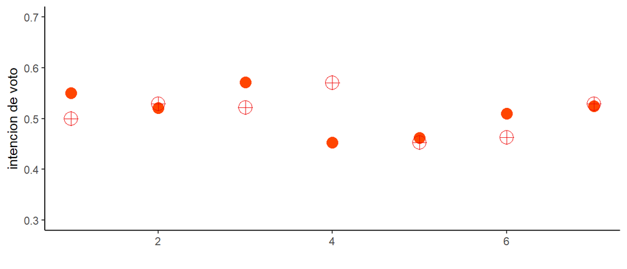

```r
library(tidyverse)

#Muestreo de la distribucion posterior
posterior <- as.matrix(logis_fit)

# Parametros vs Observados
ps <- posterior %>% as.tibble() %>% select(7:13) %>% summarize_all(funs(mean)) %>% t() %>% as.data.frame()

# Convertir parametros con funcion inversa logistica
inv_log <- function(x) {
  1/(1+exp(-x))
}
ps <- ps %>% mutate_all(funs(inv_log))

#Valores observados
obs <- d %>% mutate(id = id/n,t=seq(from=1,to=7))

#Bind
ps_obs <- cbind(ps,obs)

#Grafica
ggplot(ps_obs, aes(x=t))+
    geom_point(aes(y=id),size=4,color="orangered")+
    geom_point(aes(y=ps),shape=10,size=5,color="red2")+
    theme_classic()+labs(y="intencion de voto",x="")+
  ylim(0.3,0.7)
```

Para terminar, vamos las densidades de los parámetros estimados usando bayesplot y lanzar shinystan:

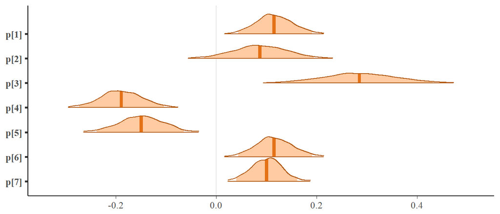

```r
#Grafica
library(bayesplot)
posterior <- as.matrix(logis_fit)
color_scheme_set("orange")
mcmc_areas(posterior,prob=0.95,prob_outer = 0.99,point_est="mean",pars=c("p[1]","p[2]","p[3]","p[4]","p[5]","p[6]","p[7]"))
```

```r
#Shinystan
library(shinystan)
launch_shinystan(logis_fit)
```

### Bonus: Estimación con map2stan

Además de la siempre abstrusa representación del código en RStan, en este postre incluyo una alternativa que de paso le hace bombo al paquete [rethinking](http://xcelab.net/R/rethinking_package.pdf) que preparó uno de los mejores cocineros: [Richard McElreath](http://xcelab.net/rm/).

La especificación del modelo en el código del paquete rethinking, que traduce a un lenguaje más amable el código de RStan, se ve así:

```r
library(rethinking)

# Modelo logístico en map2stan:
logis <- map2stan(
  alist(
    #modelo
    id ~ dbinom(n,p),
    logit(p) <- a[encuestadora],
    #priors
    a[encuestadora] ~ dnorm(a,s),
    a ~ dnorm(50,5),
    s ~ dcauchy(0,5)
     ),
  data=d,
  control=list(adapt_delta=0.96),
  iter=4000, warmup=1000, chains=4, cores=2)
```

## Referencias

[Este proyecto](https://pkremp.github.io/report.html) de Pierre-Antoine Kremp, para las presidenciales en EEUU de 2016, fue la inspiración para estas recetas.  
McElreath, R. (2015). [Statistical Rethinking](http://xcelab.net/rm/statistical-rethinking/). Texts in Statistical Science. Bendito sea Richard McElreath por este texto.  
Stan Development Team (2016) [Stan Modeling Language: User’s Guide and Reference Manual. Version 2.14.0.](https://github.com/stan-dev/stan/releases/download/v2.17.0/stan-reference-2.17.0.pdf)  
Gelman, A. (2006). [Prior distributions for variance parameters in hierarchical models (comment on article by Browne and Draper)](https://projecteuclid.org/download/pdf_1/euclid.ba/1340371048). Bayesian analysis, 1(3), pp.515-534.  
Linzer, D. A. (2013). [Dynamic Bayesian forecasting of presidential elections in the states](https://www.ocf.berkeley.edu/~vsheu/Midterm%202%20Project%20Files/Linzer-prespoll-May12.pdf). Journal of the American Statistical Association, 108(501), 124-134.  
Wickham, H., & Grolemund, G. (2016). [R for data science: import, tidy, transform, visualize, and model data.](http://r4ds.had.co.nz/) O’Reilly Media, Inc.